# Linear Discriminant Analysis II

## Types of Errors

Let's say you work for a bank and you're tasked with building a model that will predict whether someone will default given their credit history (i.e. balance).

What could go wrong?

```r
conf_log
```

```
##
## my_log_pred   No  Yes
##         No  9625  233
##         Yes   42  100
```

1. Deny credit to someone who would not have defaulted (false positive)
2. Give credit to somone who will default (false negative)

What could we change to lower our false positive rate?

```r
my_log_pred <- ifelse(m1$fit < 0.6, "No", "Yes")
conf_log_6 <- table(my_log_pred, Default$default)
conf_log_6
```

```
##
## my_log_pred   No  Yes
##         No  9643  258
##         Yes   24   75
```

```r
conf_log
```

```
##
## my_log_pred   No  Yes
##         No  9625  233
##         Yes   42  100
```

And if we raise the threshold a bit more?

```r
my_log_pred <- ifelse(m1$fit < 0.7, "No", "Yes")
conf_log_7 <- table(my_log_pred, Default$default)
conf_log_7
```

```
##
## my_log_pred   No  Yes
##         No  9654  284
##         Yes   13   49
```

```r
conf_log_6
```

```
##
## my_log_pred   No  Yes
##         No  9643  258
##         Yes   24   75
```

## False positive rate

Of all of the actual negatives, how many did we declare positive?

\[ FPR = FP / (FP + TN) \]

```r
thresh <- c(0.5, 0.6, 0.7)
FPR <- c(conf_log["Yes", "No"]/sum(conf_log[, "No"]),
        conf_log_6["Yes", "No"]/sum(conf_log_6[, "No"]),
        conf_log_7["Yes", "No"]/sum(conf_log_7[, "No"]))
FPR
```

```
## [1] 0.004344678 0.002482673 0.001344781
```

## True positive rate

Of all of the actual positives, how many did we declare positive?

\[ TPR = TP / (TP + FN) \]

```r
thresh <- c(0.5, 0.6, 0.7)
TPR <- c(conf_log["Yes", "Yes"]/sum(conf_log[, "Yes"]),
        conf_log_6["Yes", "Yes"]/sum(conf_log_6[, "Yes"]),
        conf_log_7["Yes", "Yes"]/sum(conf_log_7[, "Yes"]))
TPR
```

```
## [1] 0.3003003 0.2252252 0.1471471
```

## ROC curve

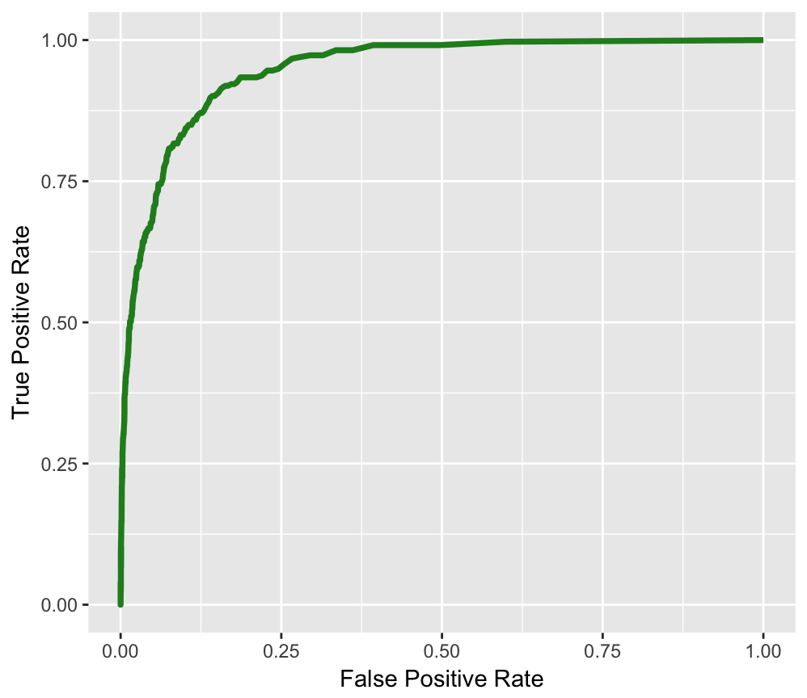

## LDA with p > 1, K > 2

## Example: Fisher's Irises

[figure not shown]

```r
head(iris)
```

```
##   Sepal.Length Sepal.Width Petal.Length Petal.Width Species
## 1          5.1         3.5          1.4         0.2  setosa
## 2          4.9         3.0          1.4         0.2  setosa
## 3          4.7         3.2          1.3         0.2  setosa
## 4          4.6         3.1          1.5         0.2  setosa
## 5          5.0         3.6          1.4         0.2  setosa
## 6          5.4         3.9          1.7         0.4  setosa
```

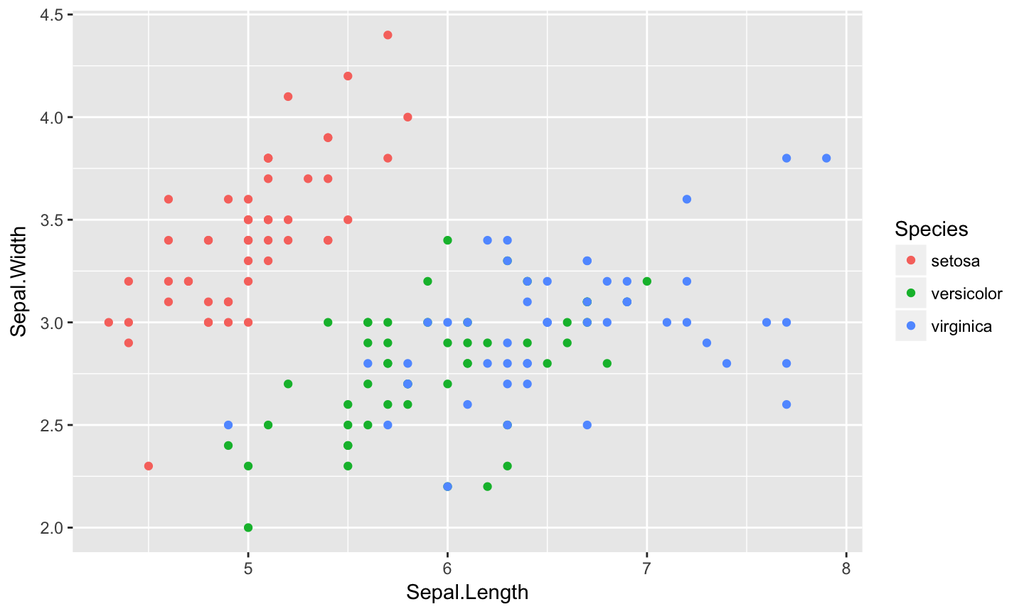

LDA can be done more quickly using the `lda()` function in the `MASS` package.

```r
library(MASS)
mlda <- lda(Species ~ Sepal.Length + Sepal.Width, data = iris)
mlda_pred <- predict(mlda)
(conf <- table(mlda_pred$class, iris$Species))
```

```
##
##              setosa versicolor virginica
##   setosa         49          0         0
##   versicolor      1         36        15
##   virginica       0         14        35
```

### Misclassification Rate

```r
(sum(conf) - sum(diag(conf)))/sum(conf)
```

```
## [1] 0.2
```

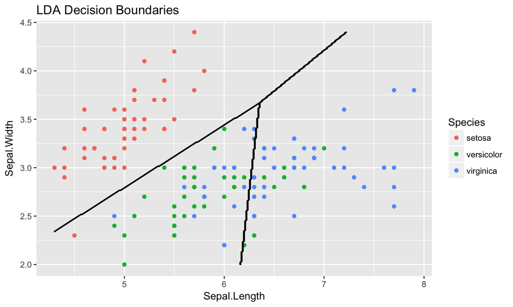

## LDA summary

- Focuses on modeling the predictors: \(f_k(X) = \textrm{Normal}(\mu_k, \sum)\)
- Uses Bayes Rule to find the probabilities that an observation in is each class given the probabilities of all the \(\pi_k f_k(X)\).

**Note**

- Allows each class to have its own \(\mu_k\).
- Constrains \(\sum\) to be shared between the classes (inducing linear decision boundaries).

*Question*

On data set with 15 predictors and 1000 observations, would you worry more about the *bias* or the *variance* of this method?

## Quadratic DA

Focuses on modeling the predictors: \(f_k(X) = \textrm{Normal}(\mu_k, \sum_k)\)

*Allow each class to have it's own covariance matrix*

## QDA

```r
mqda <- qda(Species ~ Sepal.Length + Sepal.Width, data = iris)
mqda_pred <- predict(mqda)
(conf <- table(mqda_pred$class, iris$Species))
```

```
##
##              setosa versicolor virginica
##   setosa         49          0         0
##   versicolor      1         37        16
##   virginica       0         13        34
```

### Misclassification Rate

```r
(sum(conf) - sum(diag(conf)))/sum(conf)
```

```
## [1] 0.2
```

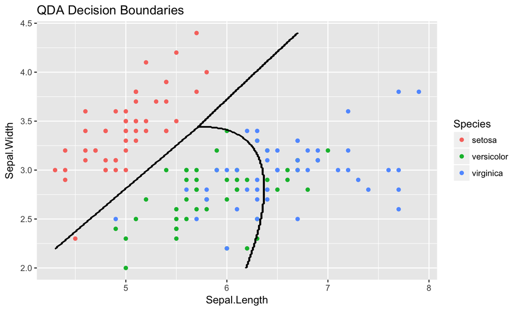